# Group Project Report

2022-12-29

# Introduction

### Team member

| Name | Student ID |
| --- | --- |
| Samuel Tan Joo Woon | S2196123 |
| Chandra Mohan | 22050516 |
| Ng Boon Sheng | 22050617 |
| Nurul Auni | 17098058 |
| Siti Norhafiza Jahaya | S2181108 |

## Project Objective

A bank wants to automate the loan eligibility process based on customer details submitted through online application form. The details filled by the customer are Gender, Marital Status, Education, Number of Dependents, Income of self and co applicant, Required Loan Amount, Required Loan Term, Credit History and others. The requirements are as follows:

1. Check eligibility of the Customer given the inputs described above. (Classification)
2. Predict loan amount to be approved given the inputs described above. (Regression)

## Project Methodology

This project is using OSEMN model.

**OBTAIN:** The dataset is obtain through [Kaggle](https://www.kaggle.com/datasets/yashpaloswal/loan-prediction-with-3-problem-statement). The link is as followed: https://www.kaggle.com/datasets/yashpaloswal/loan-prediction-with-3-problem-statement

**SCRUB:** The dataset come with splitted training set, testing set and sample_submission in csv file. Some action have been taken in data cleaning process to clean and generate new training and testing set.

**EXPLORATORY:**

**MODEL:**

Listed below are the machine learning algorithms that will be used in regression modelling for loan amount approval prediction: 1. Extreme Gradient Boosting (XGBoost) 2. Support Vector Regression (SVR) 3. K-Nearest Neighbor(KNN) 4. Linear Regression 5. Random Forest (RF)

**INTEPRET:**

For regression modelling: Root Mean Square Error (RMSE) and R Squared value will be used to evaluate the performance of model developed and the best model will be chosen as the final model for loan amount approval prediction.

# 1. Data Cleaning

#### 1.0 Import the necessary library

```r
if(!require("dplyr")) { install.packages("dplyr")  }
if(!require('tidyr')) { install.packages('tidyr') }
if(!require('DescTools')) { install.packages('DescTools') }
if(!require('VIM')) { install.packages('VIM') }
```

```
## VIM is ready to use.
```

```
## Suggestions and bug-reports can be submitted at: https://github.com/statistikat/VIM/issues
```

```r
library(dplyr)
library('tidyr')
library('DescTools')
library('VIM')

setwd(dirname(rstudioapi::getSourceEditorContext()$path))
```

#### 1.1 Combine dataset into one new dataset

```r
# Prequel: Combine all dataset into one new dataset
training_set = read.csv("./Data/training_set.csv")
testing_set = read.csv("./Data/testing_set.csv")
sample_submission = read.csv("./Data/sample_submission.csv")

head(sample_submission)
```

```
##   X  Loan_ID Loan_Status
## 1 0 LP001015           Y
## 2 1 LP001022           Y
## 3 2 LP001031           Y
## 4 3 LP001035           Y
## 5 4 LP001051           Y
## 6 5 LP001054           Y
```

```r
head(testing_set)
```

```
##    Loan_ID Gender Married Dependents    Education Self_Employed ApplicantIncome
## 1 LP001015   Male     Yes          0     Graduate            No            5720
## 2 LP001022   Male     Yes          1     Graduate            No            3076
## 3 LP001031   Male     Yes          2     Graduate            No            5000
## 4 LP001035   Male     Yes          2     Graduate            No            2340
## 5 LP001051   Male      No          0 Not Graduate            No            3276
## 6 LP001054   Male     Yes          0 Not Graduate           Yes            2165
##   CoapplicantIncome LoanAmount Loan_Amount_Term Credit_History property_Area
## 1                 0        110              360              1         Urban
## 2              1500        126              360              1         Urban
## 3              1800        208              360              1         Urban
## 4              2546        100              360             NA         Urban
## 5                 0         78              360              1         Urban
## 6              3422        152              360              1         Urban
```

```r
## combine testing set with its approval status
combined_testing_sample = inner_join(testing_set, sample_submission[, c("Loan_ID", "Loan_Status")], by = "Loan_ID")
head(combined_testing_sample)
```

```
##    Loan_ID Gender Married Dependents    Education Self_Employed ApplicantIncome
## 1 LP001015   Male     Yes          0     Graduate            No            5720
## 2 LP001022   Male     Yes          1     Graduate            No            3076
## 3 LP001031   Male     Yes          2     Graduate            No            5000
## 4 LP001035   Male     Yes          2     Graduate            No            2340
## 5 LP001051   Male      No          0 Not Graduate            No            3276
## 6 LP001054   Male     Yes          0 Not Graduate           Yes            2165
##   CoapplicantIncome LoanAmount Loan_Amount_Term Credit_History property_Area
## 1                 0        110              360              1         Urban
## 2              1500        126              360              1         Urban
## 3              1800        208              360              1         Urban
## 4              2546        100              360             NA         Urban
## 5                 0         78              360              1         Urban
## 6              3422        152              360              1         Urban
##   Loan_Status
## 1           Y
## 2           Y
## 3           Y
## 4           Y
## 5           Y
## 6           Y
```

```r
## Check if colnames is matched
print(colnames(training_set) == colnames(combined_testing_sample))
```

```
##  [1] TRUE TRUE TRUE TRUE TRUE TRUE TRUE TRUE TRUE TRUE TRUE TRUE TRUE
```

```r
combined_training_testing = rbind(combined_testing_sample,training_set) %>% arrange(Loan_ID)
head(combined_training_testing)
```

```
##    Loan_ID Gender Married Dependents    Education Self_Employed ApplicantIncome
## 1 LP001002   Male      No          0     Graduate            No            5849
## 2 LP001003   Male     Yes          1     Graduate            No              NA
## 3 LP001005   Male     Yes          0     Graduate           Yes            3000
## 4 LP001006   Male     Yes          0 Not Graduate            No            2583
## 5 LP001008   Male      No          0     Graduate            No            6000
## 6 LP001011            Yes          2     Graduate           Yes            5417
##   CoapplicantIncome LoanAmount Loan_Amount_Term Credit_History property_Area
## 1                 0         NA              360              1         Urban
## 2              1508        128              360              1         Rural
## 3                 0         66              360              1         Urban
## 4              2358        120              360              1         Urban
## 5                 0        141              360              1         Urban
## 6              4196        267              360              1         Urban
##   Loan_Status
## 1           Y
## 2           N
## 3           Y
## 4           Y
## 5           Y
## 6           Y
```

```r
## Write new combined dataset
write.csv(combined_training_testing, "./Data/combined_training_testing.csv", row.names = FALSE)

dataset = read.csv("./Data/combined_training_testing.csv")
head(dataset)
```

```
##    Loan_ID Gender Married Dependents    Education Self_Employed ApplicantIncome
## 1 LP001002   Male      No          0     Graduate            No            5849
## 2 LP001003   Male     Yes          1     Graduate            No              NA
## 3 LP001005   Male     Yes          0     Graduate           Yes            3000
## 4 LP001006   Male     Yes          0 Not Graduate            No            2583
## 5 LP001008   Male      No          0     Graduate            No            6000
## 6 LP001011            Yes          2     Graduate           Yes            5417
##   CoapplicantIncome LoanAmount Loan_Amount_Term Credit_History property_Area
## 1                 0         NA              360              1         Urban
## 2              1508        128              360              1         Rural
## 3                 0         66              360              1         Urban
## 4              2358        120              360              1         Urban
## 5                 0        141              360              1         Urban
## 6              4196        267              360              1         Urban
##   Loan_Status
## 1           Y
## 2           N
## 3           Y
## 4           Y
## 5           Y
## 6           Y
```

#### 1.2 Check and deal the missing value

```r
# Check number of empty value in a dataset
print.numOfEmtpyValue <- function(data) {
  # create empty matrix
  df <- data.frame(matrix(ncol = 2, nrow = 0))
  colnames(df) = c("Column_Names", "Num_Of_Empty_Value")

  for(i in 1:ncol(data)) {
    df[nrow(df) + 1,] <- c(colnames(data)[i], sum(is.na(data[, i])|is.null(data[, i])|data[, i] == ""))
  }
  print(df)
}

# Convert column that have empty string to NA
dataset = na_if(dataset, "")
print.numOfEmtpyValue(dataset)
```

```
##         Column_Names Num_Of_Empty_Value
## 1            Loan_ID                  0
## 2             Gender                 26
## 3            Married                  3
## 4         Dependents                 25
## 5          Education                  1
## 6      Self_Employed                 55
## 7    ApplicantIncome                  2
## 8  CoapplicantIncome                  1
## 9         LoanAmount                 27
## 10  Loan_Amount_Term                 20
## 11    Credit_History                 79
## 12     property_Area                  0
## 13       Loan_Status                  0
```

#### 1.3 Impute the missing value according to the attribute nature

```r
# 1.3.1 Sequential, Random Hot deck imputation on categorical Columns with less empty value (Married, Education)
dataset = hotdeck(dataset, variable = c("Married"), domain_var = c("Gender", "Dependents", "Education", "Self_Employed", "Credit_History", "Loan_Status"), imp_var=FALSE)
dataset = hotdeck(dataset, variable = c("Education"), domain_var = c("Gender", "Dependents", "Married", "Self_Employed", "Credit_History", "Loan_Status"), imp_var=FALSE)

print.numOfEmtpyValue(dataset)
```

```
##         Column_Names Num_Of_Empty_Value
## 1            Loan_ID                  0
## 2             Gender                 26
## 3            Married                  0
## 4         Dependents                 25
## 5          Education                  0
## 6      Self_Employed                 55
## 7    ApplicantIncome                  2
## 8  CoapplicantIncome                  1
## 9         LoanAmount                 27
## 10  Loan_Amount_Term                 20
## 11    Credit_History                 79
## 12     property_Area                  0
## 13       Loan_Status                  0
```

```r
# 1.3.2 KNN -> Dependents, Self_Employed, Credit_History, Loan_Amount_Term
dataset = kNN(dataset, variable = c("Dependents"), dist_var = c("Gender", "Education", "Married", "Self_Employed", "Credit_History", "Loan_Status"), imp_var=FALSE)
dataset = kNN(dataset, variable = c("Self_Employed"), dist_var = c("Gender", "Dependents", "Married", "Education", "Credit_History", "Loan_Status"), imp_var=FALSE)
dataset = kNN(dataset, variable = c("Credit_History"), dist_var = c("Gender", "Dependents", "Married", "Self_Employed", "Education", "Loan_Status"), imp_var=FALSE)
dataset = kNN(dataset, variable = c("Loan_Amount_Term"), dist_var = c("ApplicantIncome", "CoapplicantIncome", "LoanAmount", "property_Area", "Credit_History", "Loan_Status"), imp_var=FALSE)

print.numOfEmtpyValue(dataset)
```

```
##         Column_Names Num_Of_Empty_Value
## 1            Loan_ID                  0
## 2             Gender                 26
## 3            Married                  0
## 4         Dependents                  0
## 5          Education                  0
## 6      Self_Employed                  0
## 7    ApplicantIncome                  2
## 8  CoapplicantIncome                  1
## 9         LoanAmount                 27
## 10  Loan_Amount_Term                  0
## 11    Credit_History                  0
## 12     property_Area                  0
## 13       Loan_Status                  0
```

```r
# 1.3.3 Regression Imputation -> ApplicantIncome, CoapplicantIncome, LoanAmount
dataset = regressionImp(ApplicantIncome~Gender+Self_Employed, data=dataset, imp_var=FALSE)
dataset = regressionImp(LoanAmount~Gender+Dependents+Married+Self_Employed+ApplicantIncome+CoapplicantIncome+Credit_History+property_Area+Loan_Status, data=dataset, imp_var=FALSE)

# 1.3.4 Replace NA value in "CoapplicantIncome" with 0 (default value)
dataset["CoapplicantIncome"] = dataset$CoapplicantIncome %>% replace_na(0)

# Check on the missing value
print.numOfEmtpyValue(dataset)
```

```
##         Column_Names Num_Of_Empty_Value
## 1            Loan_ID                  0
## 2             Gender                 26
## 3            Married                  0
## 4         Dependents                  0
## 5          Education                  0
## 6      Self_Employed                  0
## 7    ApplicantIncome                  0
## 8  CoapplicantIncome                  0
## 9         LoanAmount                  0
## 10  Loan_Amount_Term                  0
## 11    Credit_History                  0
## 12     property_Area                  0
## 13       Loan_Status                  0
```

```r
# 1.4.1 Remove unimportant column
dataset <- subset (dataset, select = -c(Loan_ID, Gender))

# 1.4.2 Convert LoanAmount into 100k base
dataset["LoanAmount"] = round(dataset["LoanAmount"] * 1000)

head(dataset)
```

```
##   Married Dependents    Education Self_Employed ApplicantIncome
## 1      No          0     Graduate            No        5849.000
## 2     Yes          1     Graduate            No        4995.706
## 3     Yes          0     Graduate           Yes        3000.000
## 4     Yes          0 Not Graduate            No        2583.000
## 5      No          0     Graduate            No        6000.000
## 6     Yes          2     Graduate           Yes        5417.000
##   CoapplicantIncome LoanAmount Loan_Amount_Term Credit_History property_Area
## 1                 0     116904              360              1         Urban
## 2              1508     128000              360              1         Rural
## 3                 0      66000              360              1         Urban
## 4              2358     120000              360              1         Urban
## 5                 0     141000              360              1         Urban
## 6              4196     267000              360              1         Urban
##   Loan_Status
## 1           Y
## 2           N
## 3           Y
## 4           Y
## 5           Y
## 6           Y
```

#### 1.5 Apply label encoding on the categorical data

```r
dataset$Married = ifelse(dataset$Married == "Yes", 1, 0)
dataset['Dependents'][dataset['Dependents'] == "3+"] = 3
dataset$Education = ifelse(dataset$Education == "Graduate", 1, 0)
dataset$Self_Employed = ifelse(dataset$Self_Employed == "Yes", 1, 0)
dataset$property_Area = as.numeric(factor(dataset$property_Area))
dataset$Loan_Status = ifelse(dataset$Loan_Status == "Y", 1, 0)
```

#### 1.6 Split the data into new training and testing set

```r
# 1.6 Split into training and testing set
set.seed(1)
sample <- sample(c(TRUE, FALSE), nrow(dataset), replace=TRUE, prob=c(0.8,0.2))
training_set  <- dataset[sample, ]
testing_set   <- dataset[!sample, ]

write.csv(dataset, "./Data/processed_dataset.csv", row.names = FALSE)
write.csv(training_set, "./Data/processed_training_set.csv", row.names = FALSE)
write.csv(testing_set, "./Data/processed_testing_set.csv", row.names = FALSE)

reg_dataset=dataset[dataset$Loan_Status==1,]
reg_sample = sample(c(TRUE, FALSE), nrow(reg_dataset), replace=TRUE, prob=c(0.8,0.2))
reg_training_set  = reg_dataset[reg_sample, ]
reg_testing_set   = reg_dataset[!reg_sample, ]

write.csv(reg_dataset, "./Data/reg_processed_dataset.csv", row.names = FALSE)
write.csv(reg_training_set, "./Data/reg_processed_training_set.csv", row.names = FALSE)
write.csv(reg_testing_set, "./Data/reg_processed_testing_set.csv", row.names = FALSE)

glimpse(training_set)
```

```
## Rows: 785
## Columns: 11
## $ Married           <dbl> 0, 1, 1, 0, 1, 1, 1, 1, 1, 1, 1, 1, 0, 1, 0, 0, 0, 1…
## $ Dependents        <chr> "0", "1", "0", "0", "3", "0", "2", "1", "1", "2", "2…
## $ Education         <dbl> 1, 1, 1, 1, 1, 1, 0, 1, 1, 1, 1, 1, 1, 1, 1, 0, 1, 0…
## $ Self_Employed     <dbl> 0, 0, 1, 0, 0, 0, 0, 0, 0, 0, 0, 0, 0, 0, 0, 0, 0, 0…
## $ ApplicantIncome   <dbl> 5849.000, 4995.706, 3000.000, 6000.000, 3036.000, 57…
## $ CoapplicantIncome <dbl> 0, 1508, 0, 0, 2504, 0, 1526, 10968, 1500, 700, 0, 8…
## $ LoanAmount        <dbl> 116904, 128000, 66000, 141000, 158000, 110000, 16800…
## $ Loan_Amount_Term  <int> 360, 360, 360, 360, 360, 360, 360, 360, 360, 360, 36…
## $ Credit_History    <int> 1, 1, 1, 1, 0, 1, 1, 1, 1, 1, 1, 1, 1, 1, 1, 1, 0, 1…
## $ property_Area     <dbl> 3, 1, 3, 3, 2, 3, 3, 2, 3, 3, 3, 3, 1, 3, 3, 3, 3, 1…
## $ Loan_Status       <dbl> 1, 0, 1, 1, 0, 1, 1, 0, 1, 1, 1, 1, 0, 1, 1, 1, 0, 0…
```

```r
glimpse(testing_set)
```

```
## Rows: 196
## Columns: 11
## $ Married           <dbl> 1, 1, 1, 1, 1, 0, 1, 0, 1, 0, 0, 1, 0, 1, 0, 1, 1, 0…
## $ Dependents        <chr> "0", "2", "0", "2", "2", "0", "0", "3", "2", "0", "0…
## $ Education         <dbl> 0, 1, 0, 1, 1, 0, 1, 1, 1, 1, 1, 1, 1, 0, 1, 1, 0, 1…
## $ Self_Employed     <dbl> 0, 1, 0, 0, 0, 0, 1, 0, 0, 0, 0, 0, 0, 0, 0, 0, 1, 0…
## $ ApplicantIncome   <dbl> 2583, 5417, 2333, 5000, 2340, 3276, 9560, 4166, 4583…
## $ CoapplicantIncome <dbl> 2358, 4196, 1516, 1800, 2546, 0, 0, 0, 2916, 0, 0, 0…
## $ LoanAmount        <dbl> 120000, 267000, 95000, 208000, 100000, 78000, 191000…
## $ Loan_Amount_Term  <int> 360, 360, 360, 360, 360, 360, 360, 180, 360, 360, 36…
## $ Credit_History    <int> 1, 1, 1, 1, 1, 1, 1, 1, 1, 1, 1, 1, 0, 1, 1, 1, 0, 1…
## $ property_Area     <dbl> 3, 3, 3, 3, 3, 3, 2, 3, 3, 3, 3, 3, 1, 2, 2, 3, 1, 3…
## $ Loan_Status       <dbl> 1, 1, 1, 1, 1, 1, 1, 1, 1, 0, 1, 1, 0, 1, 0, 1, 0, 1…
```

# 2. EDA

#### Import library

```r
#install.packages('ggplot', repos = "http://cran.us.r-project.org")
#install.packages("tidyverse", repos = "http://cran.us.r-project.org")
if(!require("ggplot2")) { install.packages("ggplot2")  }
if(!require('tidyverse')) { install.packages('tidyverse') }
library(ggplot2)
library(tidyverse)
```

#### Create df to avoid mess up with other variable

```r
df = dataset

df$Married <- as.factor(df$Married)
df$Dependents <- as.factor(df$Dependents)
df$Education <- as.factor(df$Education)
df$Self_Employed <- as.factor(df$Self_Employed)
df$ApplicantIncome <- as.numeric(df$ApplicantIncome)
df$CoapplicantIncome <- as.numeric(df$CoapplicantIncome)
df$LoanAmount <- as.numeric(df$LoanAmount)
df$Loan_Amount_Term <- as.numeric(df$Loan_Amount_Term)
df$Credit_History <- as.factor(df$Credit_History)
df$property_Area <- as.factor(df$property_Area)
df$Loan_Status <- as.factor(df$Loan_Status)
```

#### Summary of dataset

```r
summary(df)
```

```
##  Married Dependents Education Self_Employed ApplicantIncome CoapplicantIncome
##  0:348   0:559      0:219     0:862         Min.   :    0   Min.   :    0
##  1:633   1:160      1:762     1:119         1st Qu.: 2875   1st Qu.:    0
##          2:169                              Median : 3800   Median : 1103
##          3: 93                              Mean   : 5180   Mean   : 1600
##                                             3rd Qu.: 5516   3rd Qu.: 2365
##                                             Max.   :81000   Max.   :41667
##    LoanAmount     Loan_Amount_Term Credit_History property_Area Loan_Status
##  Min.   :  9000   Min.   :  6.0    0:156          1:290         0:251
##  1st Qu.:100000   1st Qu.:360.0    1:825          2:349         1:730
##  Median :128000   Median :360.0                   3:342
##  Mean   :142605   Mean   :342.6
##  3rd Qu.:162000   3rd Qu.:360.0
##  Max.   :700000   Max.   :480.0
```

#### distribution of Applications Income

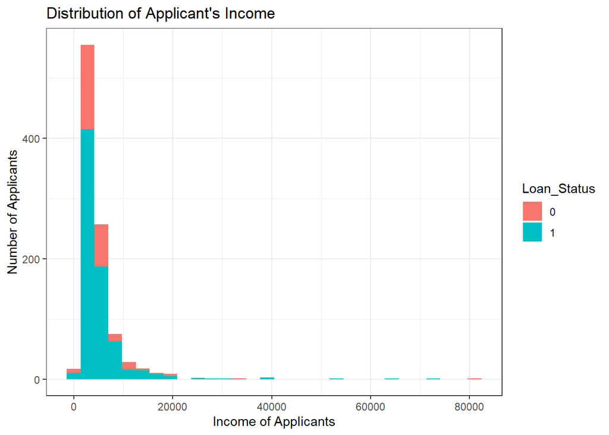

```r
ggplot(df , aes(x=ApplicantIncome,bins=5,fill=Loan_Status))+
  geom_histogram()+theme_bw()+
  labs(x="Income of Applicants",
       y= "Number of Applicants",
       title ="Distribution of Applicant's Income")
```

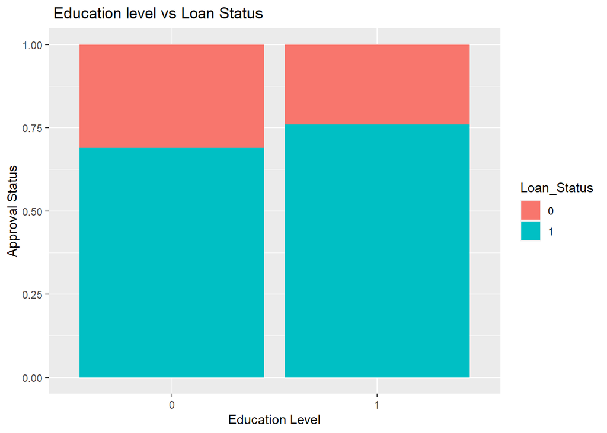

```r
plot.married <- ggplot(df, aes(x = Married, fill = Loan_Status)) +
  geom_bar()

ggplot(df, aes(x = Education, fill = Loan_Status)) +
  geom_bar(position = "fill") +
  labs(y = "Approval Status", x = 'Education Level') + ggtitle(' Education level vs Loan Status')
```

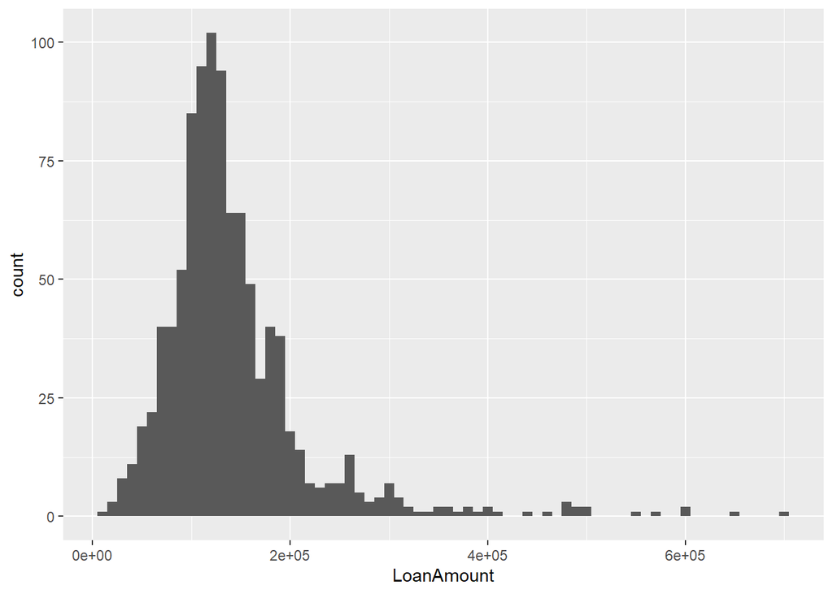

```r
ggplot(data = df, aes(LoanAmount)) + geom_histogram(binwidth = 10000)
```

# 3. Classification - To check loan eligibility of the customer

5 Classification algorithms:

1. Logistic Regression
2. Support Vector Machine
3. Naive Bayes
4. Decision Tree
5. XGBoost

#### Install packages for data manipulation, visualization and model training

```r
#install.packages("tidyverse", repos = "http://cran.us.r-project.org")
#install.packages("caret", repos = "http://cran.us.r-project.org")
#install.packages("MLmetrics", repos = "http://cran.us.r-project.org")
if(!require("tidyverse")) { install.packages("tidyverse")  }
if(!require("caret")) { install.packages("caret")  }
if(!require('MLmetrics')) { install.packages('MLmetrics') }
library(tidyverse)
library(caret)
library(MLmetrics)
```

#### Performance function

```r
get_performance_v1 <- function(y_true, y_pred){
  library(MLmetrics)
  # Convert predicted probabilities to binary labels
  y_pred_binary <- as.factor(ifelse(y_pred > 0.5, "1", "0"))
  # Convert true labels to factor
  y_true <- as.factor(y_true)
  # Make sure that the levels of y_true and y_pred_binary are the same
  levels(y_pred_binary) <- levels(y_true)
  # Confusion matrix
  cm <- confusionMatrix(y_pred_binary, y_true)
  # Accuracy
  acc <- cm$overall[1]
  # Precision
  prec <- cm$byClass[1]
  # Recall
  rec <- cm$byClass[2]
  # F1-score
  f1 <- F1_Score(y_pred_binary, y_true)
  # Return a list of evaluation metrics
  return(list(accuracy = acc, precision = prec, recall = rec, f1_score = f1, confusion_matrix = cm))
}
```

```r
#Read split dataset
train_set <- read.csv("./Data/processed_training_set.csv")
test_set <- read.csv("./Data/processed_testing_set.csv")

# Split train set into data (x_train) and target(y_train)
x_train <- train_set[,!names(train_set) %in% "Loan_Status"]
y_train = train_set$Loan_Status

# Split test set into data (x_test) and target(y_test)
x_test <- test_set[,!names(test_set) %in% "Loan_Status"]
y_test <- test_set$Loan_Status
```

#### 3.1 Logistic Regression

```r
#Building of model
set.seed(1)
logistic_def <- glm(formula = y_train ~ ., data = x_train, family = "binomial")

#Prediction using model
logistic_def_pred <- predict(logistic_def, newdata = x_test, type = "response")

#Evaluate model performance
logistic_def_result <- get_performance_v1(y_test, logistic_def_pred)
```

#### 3.2 Support Vector Machine

```r
#install.packages("e1071", repos = "http://cran.us.r-project.org")
if(!require('e1071')) { install.packages('e1071') }
library(e1071)

#Building of model
set.seed(1)
svm_model_def <- svm(y_train ~ ., data = x_train, kernel = "linear", cost = 1)

#Prediction using model
svm_pred_def <- predict(svm_model_def, x_test)

#Evaluate model performance
svm_result_def <- get_performance_v1(y_test, svm_pred_def)
```

#### 3.3 Naive Bayes

```r
#Building of model
set.seed(1)
nb_model_def <- naiveBayes(x_train, y_train)

#Prediction using model
nb_pred_def <- predict(nb_model_def, x_test)

#Evaluate model performance
nb_pred_def_numeric <- as.numeric(nb_pred_def)
nb_result_def <- get_performance_v1(y_test, nb_pred_def_numeric)
```

#### 3.4 Decision Tree

```r
#Install packages for data manipulation, visualization and model training
#install.packages("rpart", repos = "http://cran.us.r-project.org")

if(!require('rpart')) { install.packages('rpart') }
library(rpart)

#Building of model
set.seed(1)
dt_model_def <- rpart(formula = y_train ~ ., data = x_train)

#Prediction using model
dt_pred_def <- predict(dt_model_def, x_test)

#Evaluate model performance
dt_result_def <- get_performance_v1(y_test, dt_pred_def)
```

#### 3.5 XGBoost

```r
#Install packages for data manipulation, visualization and model training
#install.packages("xgboost", repos = "http://cran.us.r-project.org")
if(!require('xgboost')) { install.packages('xgboost') }
library(xgboost)

# convert data to matrix
x_train_matrix <- as.matrix(x_train)
x_test_matrix <- as.matrix(x_test)

#Building of model
set.seed(1)
xgb_model_def <- xgboost(data = x_train_matrix, label = y_train, nrounds = 100, objective = "binary:logistic")
#Prediction using model
xgb_pred_def <- predict(xgb_model_def, x_test_matrix)

#Evaluate model performance
xgb_result_def <- get_performance_v1(y_test, xgb_pred_def)
```

#### Final result dataframe to evaluate all models under classification

```r
model_results_df <- data.frame(
       Model = c("Logistic Regression", "SVM", "Naive Bayes", "Decision Tree", "XGBoost"),
       Accuracy = c(logistic_def_result$accuracy, svm_result_def$accuracy, nb_result_def$accuracy, dt_result_def$accuracy, xgb_result_def$accuracy),
       Precision = c(logistic_def_result$precision, svm_result_def$precision, nb_result_def$precision, dt_result_def$precision, xgb_result_def$precision),
       Recall = c(logistic_def_result$recall, svm_result_def$recall, nb_result_def$recall, dt_result_def$recall, xgb_result_def$recall),
       F1_Score = c(logistic_def_result$f1_score, svm_result_def$f1_score, nb_result_def$f1_score, dt_result_def$f1_score, xgb_result_def$f1_score))

print(model_results_df)
```

```
##                 Model  Accuracy Precision    Recall  F1_Score
## 1 Logistic Regression 0.8724490 0.5686275 0.9793103 0.6987952
## 2                 SVM 0.8724490 0.5686275 0.9793103 0.6987952
## 3         Naive Bayes 0.2602041 1.0000000 0.0000000 0.4129555
## 4       Decision Tree 0.8724490 0.5686275 0.9793103 0.6987952
## 5             XGBoost 0.8571429 0.5882353 0.9517241 0.6818182
```

# 4. Regression - Prediction on loan amount to be approved based on dataset.

5 Regression algorithms

1. XGBoost
2. Support Vector Regression
3. K-Nearest Neighbor
4. Linear Regression
5. Random Forest

#### Data import

```r
train_set = read.csv("./Data/reg_processed_training_set.csv")
test_set = read.csv("./Data/reg_processed_testing_set.csv")
head(train_set) # shows the first 6 rows of train set
```

```
##   Married Dependents Education Self_Employed ApplicantIncome CoapplicantIncome
## 1       0          0         1             0            5849                 0
## 2       1          0         0             0            2583              2358
## 3       0          0         1             0            6000                 0
## 4       1          2         1             1            5417              4196
## 5       1          0         0             0            2333              1516
## 6       1          0         1             0            5720                 0
##   LoanAmount Loan_Amount_Term Credit_History property_Area Loan_Status
## 1     116904              360              1             3           1
## 2     120000              360              1             3           1
## 3     141000              360              1             3           1
## 4     267000              360              1             3           1
## 5      95000              360              1             3           1
## 6     110000              360              1             3           1
```

#### Split train set into data (x_train) and label(y_train)

```r
x_train = train_set[,!names(train_set) %in% c("LoanAmount","Loan_Status")]
y_train = train_set$LoanAmount
head(y_train)
```

```
## [1] 116904 120000 141000 267000  95000 110000
```

#### Split test set into data (x_test) and label(y_test)

```r
x_test=test_set[,!names(test_set) %in% c("LoanAmount","Loan_Status")]
y_test=test_set$LoanAmount
head(y_test)
```

```
## [1]  66000 168000 280000  90000  40000 114000
```

#### Function-Customised function to be called

```r
get_performance = function(arg1, arg2){
mse = mean((arg1 - arg2) ^ 2)
mae = caret::MAE(arg1, arg2)
rmse = caret::RMSE(arg1, arg2)
measure = postResample(pred = arg2, obs = arg1)
r_squared = measure[2]
cat("MSE: ", mse, "MAE: ", mae, " RMSE: ", rmse,"RSquared: ", r_squared)
output = list(mse,mae,rmse,r_squared)
return(output)
}
```

#### 4.1 XGBoost

#### Import Library

```r
if(!require("xgboost")) { install.packages("xgboost")  }
if(!require("caret")) { install.packages("caret")  }
library(xgboost)
library(caret)
set.seed(1)
```

#### XGBoost-Default Parameters

```r
xgb_train = xgb.DMatrix(data = as.matrix(x_train), label = y_train)
xgb_test = xgb.DMatrix(data = as.matrix(x_test), label = y_test)
xgboost_def = xgboost(data = xgb_train,nrounds =50)
#xgboost_def
xgboost_def_predict = predict(xgboost_def, xgb_test)
xgboost_def_result=get_performance(y_test,xgboost_def_predict)
```

```
## MSE:  2882396098 MAE:  36568.87  RMSE:  53687.95 RSquared:  0.4937486
```

#### XGBoost-Fine tuned with GridSearchCV

#### Parameters

```r
grid_tune <- expand.grid(
  nrounds = c(500,1000,1500), #number of trees
  max_depth = c(2,4,6),
  eta = c(0.025,0.05,0.1,0.3), #Learning rate
  gamma = c(0.05, 0.1, 0.5, 0.7, 0.9, 1.0),
  colsample_bytree = c(0.4, 0.6, 0.8, 1.0), #subsample ratio of columns for tree
  min_child_weight = c(1,2,3), # the larger, the more conservative the model is; can be used as a stop
  subsample = c(0.5, 0.75, 1.0) # used to prevent overfitting by sampling X% training
)
```

#### Grid tuning

This step is commented due to grid tuning requires long time to complete during every compilation, thus only the best parameters tuned (ran previously) are stored and will be implemented in this project.

```r
train_control <- trainControl(method = "cv", number=10,verboseIter = TRUE,allowParallel = TRUE)

#Commented as time consuming to run, but the best parameters are as below:
#xgb_tune <- train(x = x_train,y = y_train,trControl = train_control,tuneGrid = grid_tune,method= "xgbTree",verbose = TRUE)

#xgb_tune$bestTune
#xgb_tune
```

RMSE was used to select the optimal model using the smallest value. The final values used for the model were nrounds = 500, max_depth = 2, eta = 0.025, gamma = 0.9, colsample_bytree = 0.6, min_child_weight = 3 and subsample = 0.5.

```r
final_tune=expand.grid(
  nrounds = 500,
  max_depth = 2,
  eta = 0.025,
  gamma =  0.9,
  colsample_bytree = 0.6,
  min_child_weight = 3,
  subsample = 0.5
  )

xgb_tuned <- train(x = x_train,y = y_train,trControl = train_control,tuneGrid = final_tune,method= "xgbTree",verbose = TRUE)
#xgb_tuned
xgb_tuned_pred <- predict(xgb_tuned, x_test)
xgboost_tuned_result=get_performance(y_test,xgb_tuned_pred)
```

```
## MSE:  2764774179 MAE:  35224.97  RMSE:  52581.12 RSquared:  0.503354
```

#### 4.2 Support Vector Regression (SVR)

#### Support Vector Regression (SVR)-Default Parameters

```r
if(!require("e1071")) { install.packages("e1071")  }
if(!require("kernlab")) { install.packages("kernlab")  }
library(e1071)
library(kernlab)
svr_def <- svm(formula=y_train ~ . , data=x_train,method = 'svmRadial')
#svr_def
svr_def_pred <- predict(svr_def, x_test)
svr_def_result=get_performance(y_test,svr_def_pred)
```

```
## MSE:  3614036837 MAE:  36369.91  RMSE:  60116.86 RSquared:  0.3505337
```

#### Support Vector Regression-Fine tuned with GridSearchCV

#### Parameters

```r
set.seed(1)
svr_grid_tune <- expand.grid(
  C = c(0.01, 0.25, 0.5, 1,10,100),
  sigma = 0.1
)
```

#### Grid tuning

```r
svr_train_control <- trainControl(method = "cv", number=10)
svr_tuned <- train(x = x_train,y = y_train,trControl = svr_train_control,tuneGrid = svr_grid_tune,method = 'svmRadial',verbose = TRUE)
#svr_tuned$bestTune
#svr_tuned
svr_tuned_pred=predict(svr_tuned,x_test)
svr_tuned_result=get_performance(y_test,svr_tuned_pred)
```

```
## MSE:  3592527106 MAE:  36104.94  RMSE:  59937.69 RSquared:  0.3542952
```

#### 4.3 KNN

#### KNN-Default Parameters

```r
knn_def = knnreg(x_train, y_train)
#knn_def
knn_def_pred = predict(knn_def, x_test)
knn_def_result=get_performance(y_test,knn_def_pred)
```

```
## MSE:  3621818637 MAE:  37886.02  RMSE:  60181.55 RSquared:  0.3958522
```

#### KNN-Fine tuned with GridSearchCV

#### Parameters

```r
set.seed(1)
knn_grid_tune <- expand.grid(
  k = 1:50
  )
```

#### Grid tuning

```r
knn_train_control <- trainControl(method = "cv", number=10)
knn_tuned <- train(x = x_train,y = y_train,trControl = knn_train_control,tuneGrid = knn_grid_tune,method = 'knn',verbose = TRUE)
#knn_tuned$bestTune
#knn_tuned
knn_tuned_pred=predict(knn_tuned,x_test)
knn_tuned_result=get_performance(y_test,knn_tuned_pred)
```

```
## MSE:  3234304892 MAE:  36090.2  RMSE:  56870.95 RSquared:  0.4271179
```

#### 4.4 Linear Regression(LM)

#### Linear Regression(LM)-Default Parameter

```r
# Build Training model
lm_model <- train(x = x_train, y = y_train,method = "lm", trControl = trainControl(method='none'))
summary(lm_model)
```

```
##
## Call:
## lm(formula = .outcome ~ ., data = dat)
##
## Residuals:
##     Min      1Q  Median      3Q     Max
## -336422  -26677   -4101   20022  382442
##
## Coefficients:
##                     Estimate Std. Error t value Pr(>|t|)
## (Intercept)        6.451e+04  2.958e+04   2.181 0.029618 *
## Married            2.040e+04  5.679e+03   3.593 0.000356 ***
## Dependents         3.690e+03  2.626e+03   1.405 0.160531
## Education          1.326e+04  6.192e+03   2.142 0.032637 *
## Self_Employed      1.852e+04  7.804e+03   2.373 0.017958 *
## ApplicantIncome    7.943e+00  4.811e-01  16.510  < 2e-16 ***
## CoapplicantIncome  6.679e+00  1.198e+00   5.574 3.86e-08 ***
## Loan_Amount_Term   1.240e+02  4.092e+01   3.030 0.002561 **
## Credit_History    -4.589e+04  2.453e+04  -1.871 0.061913 .
## property_Area     -8.447e+02  3.187e+03  -0.265 0.791092
## ---
## Signif. codes:  0 '***' 0.001 '**' 0.01 '*' 0.05 '.' 0.1 ' ' 1
##
## Residual standard error: 59110 on 564 degrees of freedom
## Multiple R-squared:  0.4219, Adjusted R-squared:  0.4127
## F-statistic: 45.74 on 9 and 564 DF,  p-value: < 2.2e-16
```

```r
# Apply model for prediction
#Model_training <-predict(lm_model, x_train) # Apply model to make prediction on Training set
Model_testing <-predict(lm_model, x_test) # Apply model to make prediction on Testing set
#summary(Model_testing)
#summary(Model_training)
lm_def_result=get_performance(y_test,Model_testing)
```

```
## MSE:  3376913463 MAE:  38288.16  RMSE:  58111.22 RSquared:  0.3944786
```

#### 4.5 Random Forest

#### Random Forest (RF) - Deafult Parameters

```r
library(randomForest)
library(caret)

# Build Training model, bootstrap
rf_def <- train(x = x_train, y = y_train ,method = "ranger")
#rf_def
rf_def_pred=predict(rf_def,x_test)
rf_def_result=get_performance(y_test,rf_def_pred)
```

```
## MSE:  3047474170 MAE:  35452.28  RMSE:  55203.93 RSquared:  0.4543939
```

### Random Forest (RF) - Fine tuned with Grid

```r
# K-Fold Cross Validation
ctrl<- trainControl(method="cv", number=10)
# Hyperparameter Tuning

tgrid <- expand.grid(
  mtry = 2:4,
  splitrule = "variance",
  min.node.size = c(5,10, 20)
)

rf_tuned = train(x = x_train, y = y_train,trControl = ctrl,method = "ranger",tuneGrid = tgrid)
#rf_tuned

# Apply model to make prediction on Testing set
rf_tuned_predict = predict(rf_tuned, x_test)
rf_tuned_result = get_performance(y_test, rf_tuned_predict)
```

```
## MSE:  2869501477 MAE:  34311.71  RMSE:  53567.73 RSquared:  0.4847245
```

#### Final Result DataFrame

A summary of the regression mdodels developed on respective Mean Square Error (MSE), Mean Absolute Error (MAE). Root Mean Square Error (RMSE) and R Squared values.

```r
Name = c('XGBoost-Default','XGBosot-Grid Tuned','SVM Regression-Default','SVM Regression-Grid Tune','kNN-Default','kNN-Grid Tune','Linear Regression-Default','Random Forest-Default','Random Forest-Grid Tuned')
MSE = c(xgboost_def_result[[1]],xgboost_tuned_result[[1]],
      svr_def_result[[1]],svr_tuned_result[[1]],
      knn_def_result[[1]],knn_tuned_result[[1]],
      lm_def_result[[1]],
      rf_def_result[[1]],rf_tuned_result[[1]])

MAE = c(xgboost_def_result[[2]],xgboost_tuned_result[[2]],
      svr_def_result[[2]],svr_tuned_result[[2]],
      knn_def_result[[2]],knn_tuned_result[[2]],
      lm_def_result[[2]],
      rf_def_result[[2]],rf_tuned_result[[2]])

RMSE = c(xgboost_def_result[[3]],xgboost_tuned_result[[3]],
      svr_def_result[[3]],svr_tuned_result[[3]],
      knn_def_result[[3]],knn_tuned_result[[3]],
      lm_def_result[[3]],
      rf_def_result[[3]],rf_tuned_result[[3]])

R_SQUARED =c (xgboost_def_result[[4]],xgboost_tuned_result[[4]],
      svr_def_result[[4]],svr_tuned_result[[4]],
      knn_def_result[[4]],knn_tuned_result[[4]],
      lm_def_result[[4]],
      rf_def_result[[4]],rf_tuned_result[[4]])

df <- data.frame(Name,MSE,MAE,RMSE,R_SQUARED)
print (df)
```

```
##                        Name        MSE      MAE     RMSE R_SQUARED
## 1           XGBoost-Default 2882396098 36568.87 53687.95 0.4937486
## 2        XGBosot-Grid Tuned 2764774179 35224.97 52581.12 0.5033540
## 3    SVM Regression-Default 3614036837 36369.91 60116.86 0.3505337
## 4  SVM Regression-Grid Tune 3592527106 36104.94 59937.69 0.3542952
## 5               kNN-Default 3621818637 37886.02 60181.55 0.3958522
## 6             kNN-Grid Tune 3234304892 36090.20 56870.95 0.4271179
## 7 Linear Regression-Default 3376913463 38288.16 58111.22 0.3944786
## 8     Random Forest-Default 3047474170 35452.28 55203.93 0.4543939
## 9  Random Forest-Grid Tuned 2869501477 34311.71 53567.73 0.4847245
```

### Plotting of graphs

Bar charts of performance metrices (RMSE and R_Squared) vs Regression models to show model comparisons.

RMSE is the average deviation of the predictions from the observations. It is the measure of how well a regression line fits the data points. Lower RMSE value indicates a better fit of the model to the data as the differences between the predicted and true values are smaller.

R Squared is called the coefficient of determination. It provides goodness of fit of a regression model. The value 0 indicates for no-fit and 1 for perfect fit.

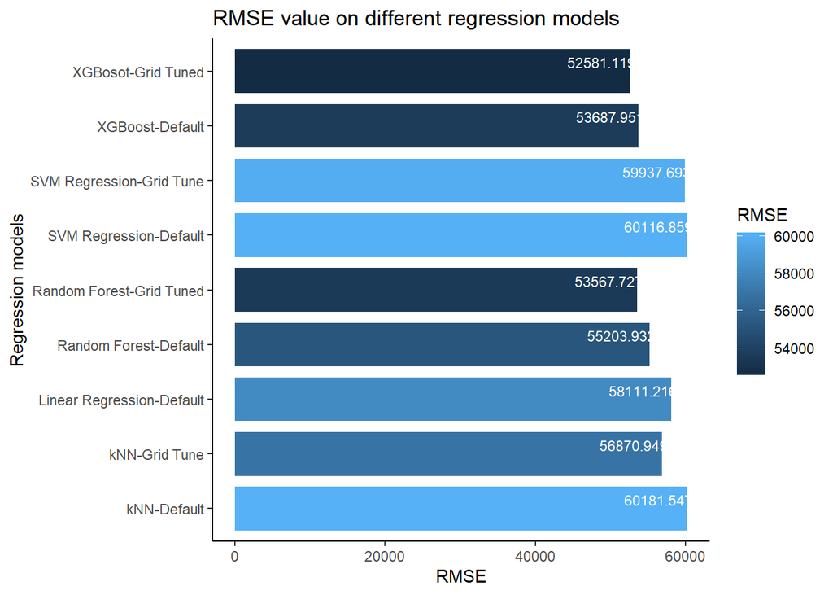

```r
library(ggplot2)
#RMSE
ggplot(data=df, aes(x=RMSE, y=Name, fill = RMSE)) +
geom_bar(stat="identity", width=0.8)+
geom_text(aes(label=RMSE), vjust=-0.3, colour="white", size=3.0)+
scale_colour_gradient2()+
theme_classic()+
ggtitle("RMSE value on different regression models") +
xlab("RMSE") +
ylab("Regression models")
```

Lower RMSE value indicates better fit of the model thus from the bar chart it is observed XGBoost-Grid Tuned model is the best model for this prediction.

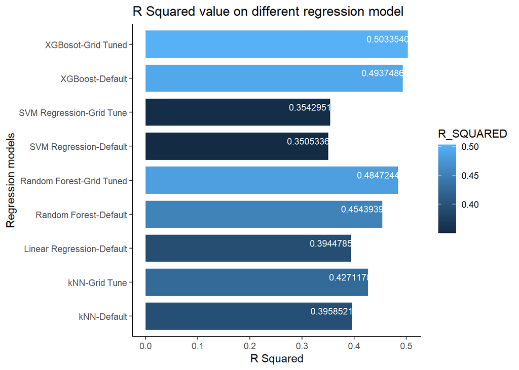

```r
# R_SQUARED
ggplot(data=df, aes(x=R_SQUARED, y=Name, fill = R_SQUARED)) +
geom_bar(stat="identity", width=0.8)+
geom_text(aes(label=R_SQUARED), vjust=-0.3, colour="white", size=3.0)+
scale_colour_gradient2()+
theme_classic()+
ggtitle("R Squared value on different regression model") +
xlab("R Squared") +
ylab("Regression models")
```

Value of 1 of R Squared indicates perfect fit, from the bar chart it is observed XGBoost-Grid Tuned model has the highest and nearest value to 1.

Based on the visualization from the RMSE and RSquared Charts plotted, it is observed that XGBoost-Grid Tuned model has the lowest RMSE value and highest R Squared value, thus it will be selected as the final model for loan amount approval prediction regression model. The comparison between actual and predicted value on the test set is plotted:

```r
# Predicted vs. Actual Values (XGBoost-Grid Tuned)
options(scipen = 999)
library(scales)
```

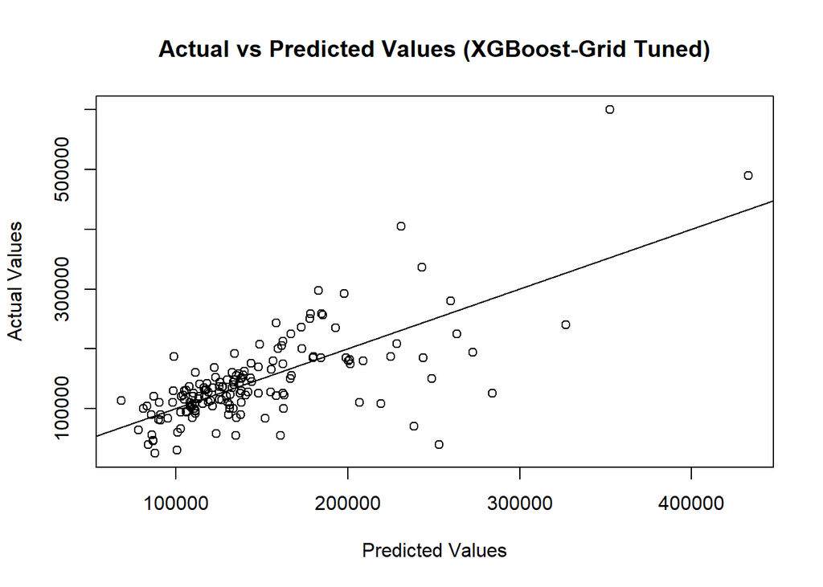

```r
plot(x=xgb_tuned_pred, y= y_test,
     xlab='Predicted Values',
     ylab='Actual Values',
     main='Actual vs Predicted Values (XGBoost-Grid Tuned)')
abline(a=0, b=1)
```

Overview on actual vs predictions of new loan amount using XGBoost tuned prediction model

```r
data <- data.frame(actual= y_test, predicted=xgb_tuned_pred)
head(data)
```

```
##   actual predicted
## 1  66000 102922.34
## 2 168000 122480.87
## 3 280000 260017.28
## 4  90000  85521.04
## 5  40000  84029.55
## 6 114000 126819.88
```

# Conclusion

In conclusion, two final prediction models are developed in this project made up of one loan approval classification prediction model and one loan amount approved regression prediction model.

In predicting the loan amount to be approved for customer, XGBoost regression model is the best model among the 5 models developed as it has the lowest Root Mean Square Error (RMSE) and highest R Squared value. However, there is still a room for improvement for the model to fit better on the dataset in future development.